# Summary report for Horley

UKMON

2017-07-18

# Summary of activity in 2017

Horley operates 1 cameras.

In 2017 Horley has recorded 129 individual meteor observations. These observations comprise 29 sporadic meteors and 100 stream meteors. A breakdown by month is shown below.

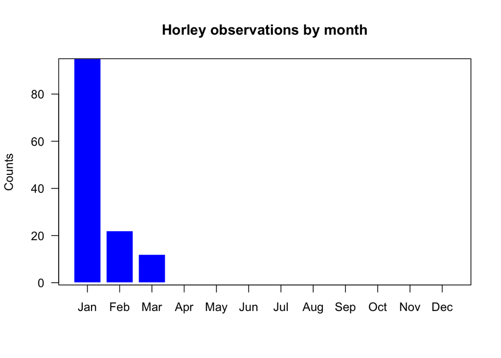

The following shows observation counts by stream for the 20 most frequent showers based on preliminary UFO ANALYSIS classifications:

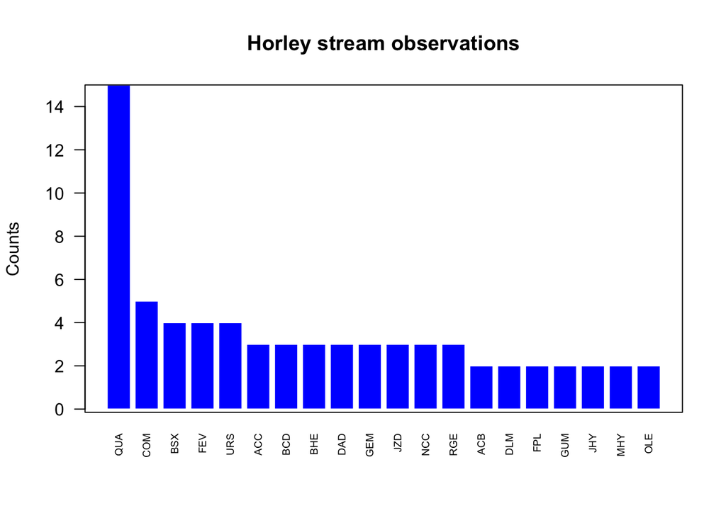

The following table shows which stations are generating matched observations with this station and the number of matches:

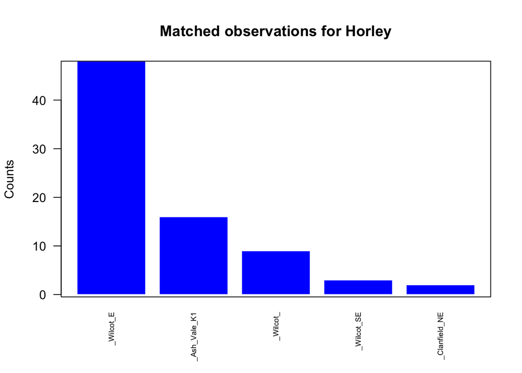

# Observations recorded by Horley, 2014 to 2017

UKMON data for Horley covers the period from 2014 to 2017 and totals 3278 individual meteor observations. These observations comprise 691 sporadic meteors and 2587 stream meteors.

This section provides a summary of all observations by Horley from 2014 to 2017. A breakdown of the number of observations by year is given in the histogram below.

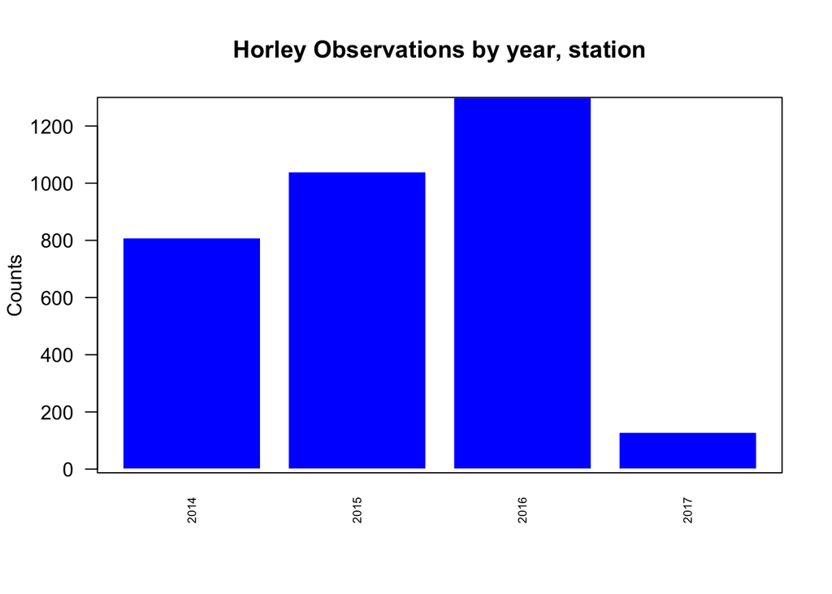

The following graph shows observation counts by stream (preliminary UFO ANALYSIS classification). A detailed breakdown by shower is given in the table at the end of this report.

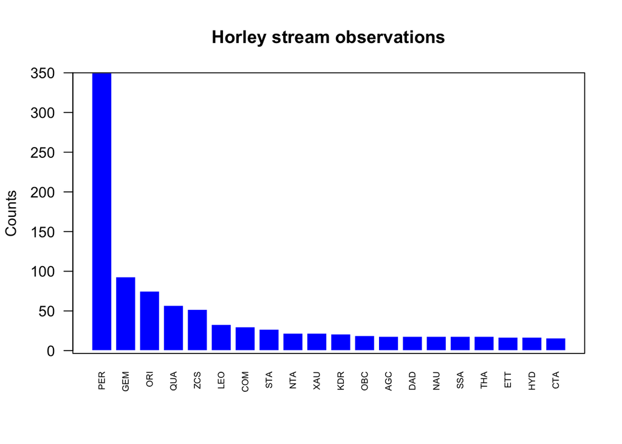

## Fireball activity

Fireballs recorded (Based on IAU definition of apparrent magnitude of -4.0 of greater)

| Datetime | Magnitude | Duration | Stream |
| --- | --- | --- | --- |
| 2014-09-14 03:51:40 | -6.1 | 0.36 | SPO |
| 2015-08-12 20:57:09 | -5.3 | 0.60 | PER |
| 2015-09-25 23:57:34 | -4.0 | 1.98 | STA |

The following table shows which stations are generating matched observations with this station and the number of matches:

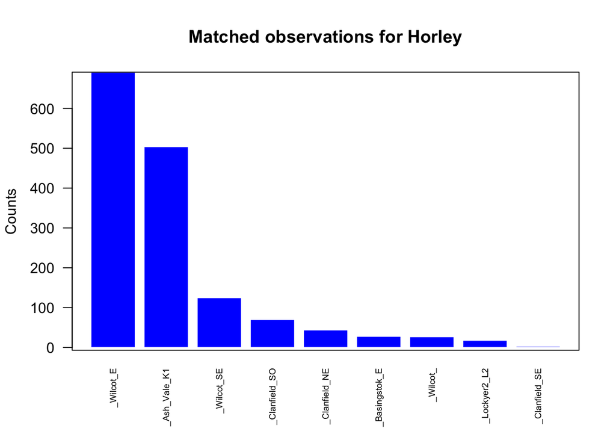

# Detailed counts (including sporadics)

| Shower | Counts |
| --- | --- |
| SPO | 691 |
| PER | 350 |
| GEM | 93 |
| ORI | 75 |
| QUA | 57 |
| ZCS | 52 |
| LEO | 33 |
| COM | 30 |
| STA | 27 |
| NTA | 22 |
| XAU | 22 |
| KDR | 21 |
| OBC | 19 |
| AGC | 18 |
| DAD | 18 |
| NAU | 18 |
| SSA | 18 |
| THA | 18 |
| ETT | 17 |
| HYD | 17 |
| CTA | 16 |
| SPE | 16 |
| EGE | 15 |
| LYR | 15 |
| NLY | 15 |
| NOO | 15 |
| NZT | 15 |
| RGE | 15 |
| DCL | 14 |
| FLY | 14 |

[output cut: 338 more lines]